# WindRose

Lucia Briganti

11/7/2021

## Visualize meteorological data!

Easy codee for the visualization of wind variable and analyzing any anomalies.

```r
# upload libraries and dataset

library(openair)
library(readxl)
```

First I Pick up the data (this file was provided by the National Weather Service and contains information about meteorological variables from an airport station).

```r
myData <- read_excel("C:/Users/Lucia/Desktop/TESIS/Datos/data meteo/dataint_meteo_2010_2020.xlsx")
myData <- na.omit(myData)
head(myData)
```

```
## # A tibble: 6 x 9
##    year month   day  hour    AT    RH    SC    WD    WS
##   <dbl> <dbl> <dbl> <dbl> <dbl> <dbl> <dbl> <dbl> <dbl>
## 1  2010     5     1     0  18    70.6     2   320  6.17
## 2  2010     5     1     1  18.3  64.4     4   320  4.63
## 3  2010     5     1     2  18.2  65.2     4   320  5.14
## 4  2010     5     1     3  18    66.1     0   320  5.66
## 5  2010     5     1     4  17    62.7     0   320  5.66
## 6  2010     5     1     5  17    60.7     0   320  5.66
```

I have hourly data, so I will add a date column and round WS (wind speed) digits, this will be useful for the wind rose.

```r
myData$date <- as.Date(with(myData, paste(year, month, day,sep="-")), "%Y-%m-%d")
myData$WS <- round(myData$WS, digits = 2)
head(myData)
```

```
## # A tibble: 6 x 10
##    year month   day  hour    AT    RH    SC    WD    WS date
##   <dbl> <dbl> <dbl> <dbl> <dbl> <dbl> <dbl> <dbl> <dbl> <date>
## 1  2010     5     1     0  18    70.6     2   320  6.17 2010-05-01
## 2  2010     5     1     1  18.3  64.4     4   320  4.63 2010-05-01
## 3  2010     5     1     2  18.2  65.2     4   320  5.14 2010-05-01
## 4  2010     5     1     3  18    66.1     0   320  5.66 2010-05-01
## 5  2010     5     1     4  17    62.7     0   320  5.66 2010-05-01
## 6  2010     5     1     5  17    60.7     0   320  5.66 2010-05-01
```

I want to visualize the historical wind pattern during winter in the city of Buenos Aires and compare it with the 2020 winter wind pattern, so for that I am plotting a wind rose for the last ten years (2010-2019) and another one for 2020. So I just subset up WS (wind speed) and WD (wind direction) from the dataframe. windRose() is a function of the openair package, very easy to use and aesthetic too.

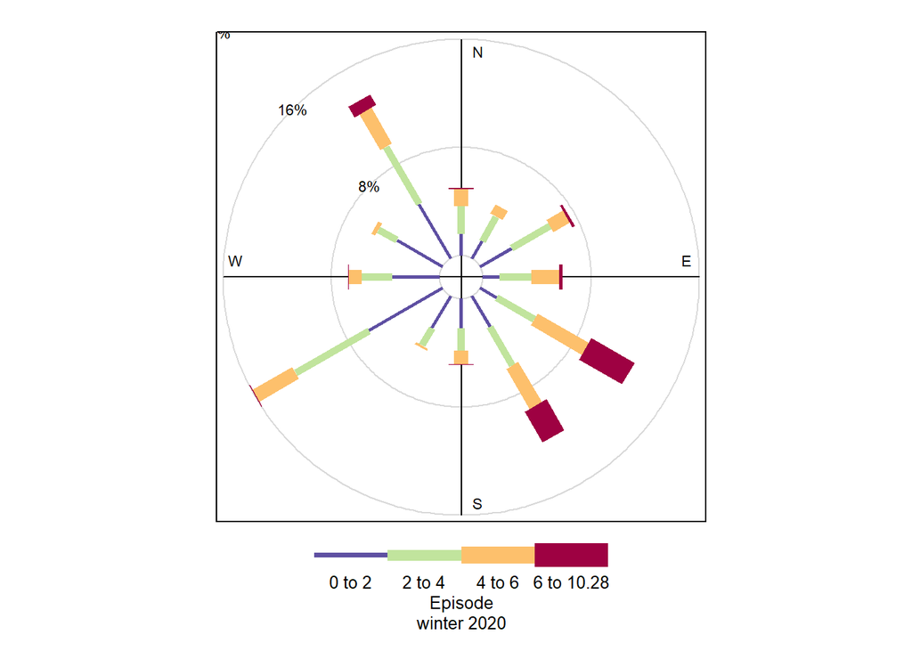

```r
plot(WR_2020)
```

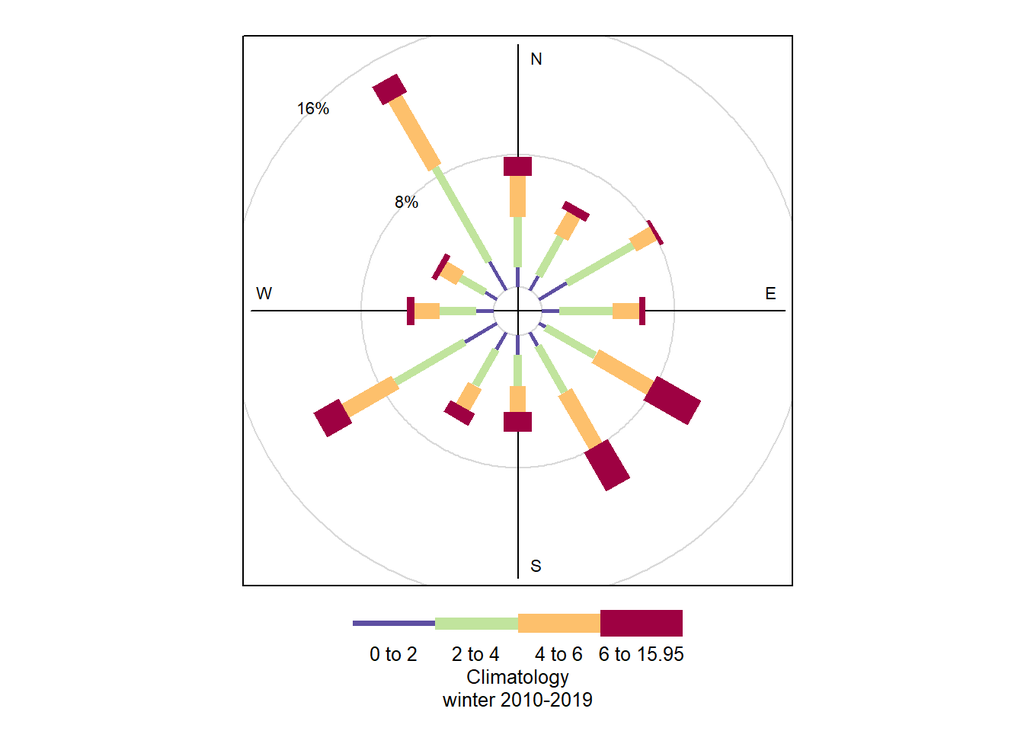

```r
plot(WR_climatica)
```

This is a qualitative analyse very useful when you are looking for wind anomalies in the wind and wanna do it quickly, it worked for me in my thesis and when analyzing a particular event. I truly recommend it: checking the event with the climatology is always a good idea. Hope it was useful =)